# Домашняя работа №1

Нагорный Олег Станиславович

Здравствуйте!

Выполнив эту работу вы научитиесь:

1. загружать данные из SPSS;
2. делать выборку нужных вам данных по определённому критерию;
3. обращаться с пропущенными значениями;
4. рассчитывать меры средних тенденций;
5. перекодировать переменные.

Срок – до 19 сентября. То есть в ночь с 18 на 19 таблица превратится в тыкву и станет недоступна для редактирования.

Сергей Николаевич подготовил [некоторые книги](https://yadi.sk/d/OlP9dhDUuxqK9), которые могут помочь в самостоятельном изучении. От себя также советую не забывать пользоваться документацией с помощью функции `help()` (или знака `?` перед именем функции, как `?mean`) и гуглом.

Итак, начнём.

## 1. Загрузите файл с данными

Скачайте базу данных [European Social Survey](http://www.europeansocialsurvey.org/). Наряду с [World Values Survey](http://www.worldvaluessurvey.org/wvs.jsp), это одно из самых масштабных межстрановых социологических исследований, авторы которого регулярно публикуют собранные данные. Некоторые из вас, вероятно, будут использовать эти базы в своих курсовых, так что полезно познакомиться с ними уже сейчас. Мы будем использовать данные шестой волны. Скачайте их по [ссылке](https://dl.dropboxusercontent.com/u/21370646/ESS6.sav).

## 2. Загрузите данные в R

Для этого вначале подключите пакет `foreign`, который позволяет читать данные из файлов, сохранённых в SPSS, STATA, SAS.

```r
library("foreign")
```

Затем используйте функцию `read.spss`, чтобы считать данные и сохранить их в переменной `data` (название переменной может быть и другим).

```r
data <- read.spss("/Users/Hun/Dropbox/Public/ESS6.sav", to.data.frame=T)
```

Фактически, мы загрузили таблицу, каждый ряд который представляет ответы респондентов на различные вопросы, которые соответствуют колонкам таблицы. Посмотрите, какие колонки (они же переменные) существуют в загруженных данных:

```r
names(data)
```

```
##  [1] "ESS6_id"        "cntry"          "ESS6_reg"       "regunit"
##  [5] "NUTS1"          "NUTS2"          "NUTS3"          "name"
##  [9] "proddate"       "idno"           "ppltrst"        "pplfair"
## [13] "pplhlp"         "polintr"        "trstprl"        "trstlgl"
## [17] "trstplc"        "trstplt"        "trstprt"        "trstep"
## [21] "sgnptit"        "pbldmn"         "stflife"        "stfeco"
## [25] "stfgov"         "stfdem"         "stfedu"         "stfhlth"
## [29] "gincdif"        "freehms"        "imsmetn"        "imdfetn"
## [33] "impcntr"        "imwbcnt"        "happy"          "rlgdgr"
## [37] "optftr"         "fltlnl"         "fltsd"          "gndr"
## [41] "agea"           "yrbrn"          "rshpsts"        "marsts"
## [45] "maritalb"       "edulvlb"        "ipcrtiv"        "imprich"
## [49] "ipeqopt"        "impsafe"        "ipmodst"        "ipgdtim"
## [53] "impfree"        "ipbhprp"        "iprspot"        "iplylfr"
## [57] "imptrad"        "impfun"         "inwtm"          "dweight"
## [61] "pspwght"        "pweight"        "c_gnipc_2012"   "c_gini_2012"
## [65] "c_hditr_2012"   "c_mpi_2012"     "c_gii_2012"     "c_ihsrate_2011"
## [69] "c_crmtot_2012"
```

Значение каждой переменной можно найти в документации к базе на сайте. Нас же интересуют переменные `cntry` (страна проживания респондента) и `agea` (возраст респондента).

Взглянем на первые шесть значений этих переменных:

```r
head(data[c("cntry", "agea")])
```

```
##     cntry agea
## 1 Albania   63
## 2 Albania   29
## 3 Albania   66
## 4 Albania   NA
## 5 Albania   59
## 6 Albania   74
```

NB: в windows путь файлу должен быть указан в таком формате: `C:\\smth_folder\\ESS.sav`, то есть необходимо использовать двойные бэкслеши вместо одинарных.

NB: аргумент `to.data.frame=T` говорит функции `read.spss`, что данные должны быть конвертированы в data frame.

## 3. Создайте выборку респондентов на основе страны проживания

В [таблице](https://docs.google.com/spreadsheets/d/1ovjCA44svYcyxraMnWJsJGX_ZjQ3a3-km8mFtMRIRTQ/edit?usp=sharing) напротив имени каждого студента указана отдельная страна. Создайте выборку респондентов из соответствующей вам страны. В дальнейшем каждый будет вести работу со своей выборкой. Для примера я возьму ответы украинцев и запишу новые данные в ту же переменную:

```r
data <- data[data$cntry == "Ukraine",]
```

Как запрашивать данные по определённому критерию, советую почитать [здесь](http://www.statmethods.net/management/subset.html), это не раз пригодится.

Посмотрите количество строк (респондентов) и столбцов (переменных) в вашей выборке:

```r
dim(data)
```

```
## [1] 2178   69
```

## 4. Рассчитайте меры средних тенденций для переменной `agea` (возраст)

Основные меры средних тенденций: арифметическая средняя, пятипроцентная урезанная средняя (с обоих концов числового ряда усекаются по 5%), медиана, мода.

Однако эти меры не могут быть расчитаны, поскольку в нашей выборке есть пропущенные значения – `NA`. Удалим пропущенные значения с помощью функции `na.omit` и сохраним новые значения в новой переменной `age_wo_missing`:

```r
age_wo_missing <- na.omit(data$agea)
```

Теперь мы можем рассчитать меры средних тенденций:

```r
mean(age_wo_missing)  # среднее
```

```
## [1] 48.5069
```

```r
mean(age_wo_missing, trim = 0.05)  # пятипроцентная урезанная средняя
```

```
## [1] 48.33708
```

```r
median(age_wo_missing)  # медиана
```

```
## [1] 49
```

В R нет встроенной функции для расчёта моды, но это возможно сделать другими способами. Расчёт моды – необязательное задание для тех, кто хочет покопаться в R сам.

Также всегда полезно представление о плотности распределения исследуемой переменной:

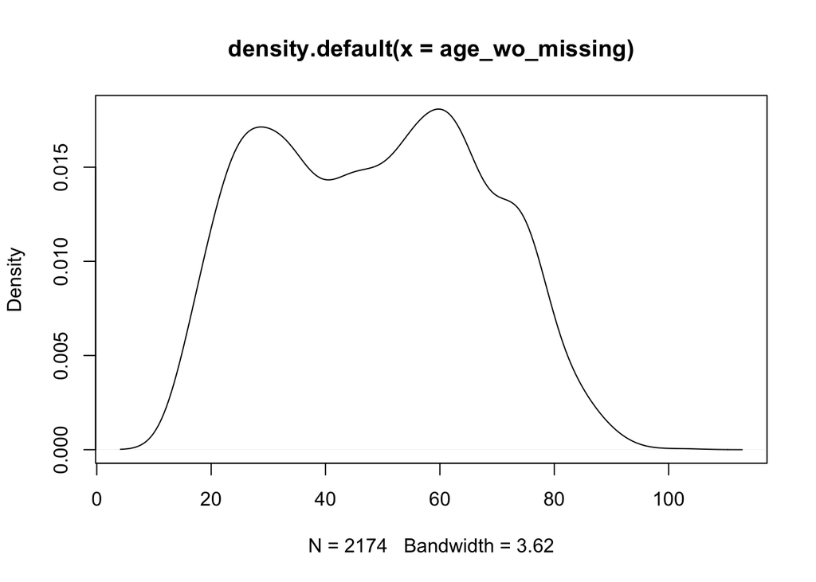

```r
plot(density(age_wo_missing))  # не совсем нормальное
```

## 5. Перекодирование переменных. Создайте переменную `is_young`, которая будет принимать значения `TRUE`, если возраст респондента менее 30 лет, и `FALSE` в ином случае. Сохраните её в той же таблице, с которой велась работа.

```r
data$is_young[data$agea < 30] <- TRUE
data$is_young[data$agea >= 30] <- FALSE
```

Более короткий способ сделать то же самое при помощи функции `ifelse` (смотрите документацию):

```r
data$is_young <- ifelse(data$agea < 30, T, F)
```

Подсчитайте количество молодёжи с помощью функции `table`:

```r
table(data$is_young)  #  в опросе приняло участие 448 молодых украинцев
```

```
##
## FALSE  TRUE
##  1726   448
```

## 6. Заполните таблицу с ответами.

https://docs.google.com/spreadsheets/d/1ovjCA44svYcyxraMnWJsJGX_ZjQ3a3-km8mFtMRIRTQ/edit?usp=sharing

# __________________________

Удачи в выполнении задания! Если возникнут вопросы, можете писать мне на почту nagornyy.o@gmail.com или спрашивать лично (доступен в 216 кабинете с 11 до 18 4 дня в неделю).